# Documentation of Preqin Data Preparation

Christian Tausch

2026-03-27

# Introduction

This document details the data preparation process for the Preqin cash flow data, as implemented in the corresponding R script. The objective is to clean, filter, and transform raw private market cash flow data into a structured format suitable for empirical asset pricing analysis. The procedure involves data loading, cleaning, calculating incremental cash flows from cumulative reports, and aggregating data into vintage year portfolios.

# Setup and Data Loading

We begin by clearing the workspace and loading necessary libraries. We also define the output directory for the prepared data.

```r
## prepare preqin
# prep ----
if (sys.nframe() == 0L) rm(list = ls())

library(readxl)
library(here)

data.prepared.folder <- here("empirical/data_prepared_2026_b")


# setwd(dirname(rstudioapi::getActiveDocumentContext()$path))
getwd()
```

```
## [1] "/Users/christausch/Library/Mobile Documents/com~apple~CloudDocs/Projects/Fundwise_SDF/r_project/empirical"
```

```r
if (!dir.exists(data.prepared.folder)) dir.create(data.prepared.folder)
```

**Note:** The working directory setup line has been commented out to ensure compatibility with R Markdown compilation.

## Loading Raw Data

The raw data is imported from an Excel spreadsheet. The script defines paths for the source file and handles potential inconsistencies in column naming (specifically regarding geographic focus).

```r
path <- "empirical/data_in/Preqin_Cashflow_export-26_Feb_20e003d5aa-5a18-4c12-aba8-7586a7435ac9.xlsx"
path <- "empirical/data_in/Preqin_Cashflow_export-14_Apr_22272f54e5-79fe-43c0-8bc0-9206381de0b7.xlsx"
path <- here(path)
sheet <- "Preqin_Export"
df.xl <- data.frame(readxl::read_excel(path = path, sheet = sheet, guess_max = 100000))
if ("GEOGRAPHIC.FOCUS" %in% colnames(df.xl)) df.xl$PRIMARY.GEOGRAPHIC.FOCUS <- df.xl$GEOGRAPHIC.FOCUS
table(df.xl$PRIMARY.GEOGRAPHIC.FOCUS)
```

```
##
##                     Afghanistan                          Africa
##                               3                             683
##                        Americas                            Asia
##                            1290                           12565
##                     Asia, China                     Australasia
##                               7                             456
##                       Australia                      Bangladesh
##                            1179                               3
##                         Belgium                          Brazil
##                               6                             582
##                        Bulgaria                          Canada
##                               5                            1139
##          Central America, China         Central and East Europe
##                              65                             638
## Central and East Europe, Poland                           China
##                               3                            2827
##                        Colombia                         Denmark
##                               6                             261
##         East and Southeast Asia                           Egypt
##                              47                               2
##                         Estonia                          Europe
##                               2                           31822
##                      Europe, US                         Finland
##                               4                             579
##                          France                         Georgia
##                             445                               6
##                         Germany                          Global
##                             269                              20
##                      Global, US                   Greater China
##                               4                             474
##                           India                       Indonesia
##                             897                             204
##                            Iran                          Israel
##                              11                            1533
##                           Italy                           Japan
##                             745                             790
##                          Latvia                       Lithuania
##                               3                              70
##                          Mexico                     Middle East
```

[output cut: 20 more lines]

```
##                             113                             199
##                           Spain              Sub-Saharan Africa
##                             144                             281
##                          Sweden                     Switzerland
##                             134                              65
##                        Thailand                          Turkey
##                             108                             352
##                              UK            United Arab Emirates
##                            5598                               2
##                              US                 US, West Europe
##                          123349                               8
##                         Vietnam                            West
##                              47                              94
##                     West Europe
##                            7353
```

```r
table(df.xl$REGION)
```

```
##
##                    Africa                      Asia               Australasia
##                      1206                     11122                      1888
##                    Europe Latin America & Caribbean               Middle East
##                     50642                      1899                      1601
##             North America
##                    245706
```

```r
colnames(df.xl)
```

```
##  [1] "FUND.ID"                    "NAME"
##  [3] "ASSET.CLASS"                "FUND.MANAGER"
##  [5] "REGION"                     "ADDRESS"
##  [7] "STATE...COUNTY"             "COUNTRY"
##  [9] "WEBSITE"                    "EMAIL"
## [11] "TEL"                        "ZIP.CODE"
## [13] "CITY"                       "FAX"
## [15] "VINTAGE...INCEPTION.YEAR"   "STRATEGY"
## [17] "FUND.SIZE..USD.MN."         "FUND.ETHOS"
## [19] "STATUS"                     "PRIMARY.REGION.FOCUS"
## [21] "CORE.INDUSTRIES"            "TRANSACTION.TYPE"
## [23] "TRANSACTION.DATE"           "TRANSACTION.AMOUNT"
## [25] "CUMULATIVE.CONTRIBUTION"    "CUMULATIVE.DISTRIBUTION"
## [27] "NET.CASHFLOW"               "QUARTILE"
## [29] "INDUSTRIES"                 "INDUSTRY.VERTICALS"
## [31] "GEOGRAPHIC.EXPOSURE"        "GEOGRAPHIC.FOCUS"
## [33] "OTHER.GEOGRAPHIES"          "FUND.CURRENCY"
## [35] "TARGET.SIZE.CURR..MN."      "FINAL.CLOSE.SIZE.CURR..MN."
## [37] "PRIMARY.GEOGRAPHIC.FOCUS"
```

```r
# Exclude too recent vintages
preqin.cutoff.vintage <- 2021
df.xl <- df.xl[df.xl$VINTAGE...INCEPTION.YEAR <= preqin.cutoff.vintage, ]

# df <- df.xl
table(df.xl$ASSET.CLASS[!duplicated(df.xl$FUND.ID)])
```

```
##
##       Hedge Funds    Infrastructure             Multi Natural Resources
##                 2               218                36               171
##      Private Debt    Private Equity       Real Estate   Venture Capital
##               623              3004              1076              1240
```

```r
table(df.xl$STRATEGY[!duplicated(df.xl$FUND.ID)])
```

```
##
##                                      Balanced
##                                            71
##                                        Buyout
##                                          1449
##                                 Co-Investment
##                                           108
##                   Co-Investment Multi-Manager
##                                            67
##                                Direct Lending
##                                            21
## Direct Lending - Blended / Opportunistic Debt
##                                            28
##   Direct Lending - Junior / Subordinated Debt
##                                            10
##                  Direct Lending - Senior Debt
##                                           140
##              Direct Lending - Unitranche Debt
##                                            10
##                            Direct Secondaries
##                                            34
##                               Distressed Debt
##                                           162
##                                   Early Stage
##                                           348
##                             Early Stage: Seed
##                                            66
##                         Early Stage: Start-up
##                                            42
##                                        Energy
##                                             4
##                        Expansion / Late Stage
##                                           153
##                                 Fund of Funds
##                                           696
##            Fund of Hedge Funds Multi-Strategy
##                                             1
##                                        Growth
##                                           386
##                  Hedge Fund Credit Strategies
```

[output cut: 48 more lines]

```
##                                           396
##                                   Secondaries
##                                           174
##                            Special Situations
##                                            89
##                                        Timber
##                                            27
##                                    Timberland
##                                             1
##                                    Turnaround
##                                            19
##                             Venture (General)
##                                           600
##                                  Venture Debt
##                                            31
```

```r
table(df.xl$VINTAGE...INCEPTION.YEAR[!duplicated(df.xl$FUND.ID)])
```

```
##
## 1982 1983 1985 1986 1987 1988 1989 1990 1991 1992 1993 1994 1995 1996 1997 1998
##    1    1    6    8    8    8    1   11   10   20   20   32   27   49   54  101
## 1999 2000 2001 2002 2003 2004 2005 2006 2007 2008 2009 2010 2011 2012 2013 2014
##  102  171  114   89   84  133  215  290  340  351  148  225  281  268  313  350
## 2015 2016 2017 2018 2019 2020 2021
##  360  387  391  382  439  337  243
```

The tables above provide an initial overview of the dataset composition across asset classes, strategies, and vintage years.

# Descriptive Statistics

## Strategy Summary

The `make.strategy.summary` function generates a summary table of the number of funds per strategy within each asset class. This helps in understanding the coverage of the dataset.

```r
make.strategy.summary <- function() {
    l <- list()
    for (asset.class in levels(as.factor(df.xl$ASSET.CLASS))) {
        # print(asset.class)
        # print(table(df.xl$STRATEGY[df.xl$ASSET.CLASS == asset.class]))
        df <- data.frame(table(df.xl$STRATEGY[(df.xl$ASSET.CLASS == asset.class) & (!duplicated(df.xl$FUND.ID))]))
        colnames(df) <- c("Strategy", "Fund Count")
        df["Asset Class"] <- asset.class
        df <- df[, c(3, 1, 2)]
        l[[asset.class]] <- df
    }
    df <- data.frame(do.call(rbind, l))

    print(
        xtable::xtable(df,
            caption = "Summary of asset classes in Preqin dataset.",
            digits = 3, label = "tab:summary_preqin_strategy"
        ),
        include.rownames = FALSE
        # , format.args = list(big.mark = ",")
    )
    return(df)
}
make.strategy.summary()
```

```
## % latex table generated in R 4.3.1 by xtable 1.8-4 package
## % Fri Mar 27 12:53:48 2026
## \begin{table}[ht]
## \centering
## \begin{tabular}{llr}
##   \hline
## Asset.Class & Strategy & Fund.Count \\
##   \hline
## Hedge Funds & Fund of Hedge Funds Multi-Strategy &    1 \\
##   Hedge Funds & Hedge Fund Credit Strategies &    1 \\
##   Infrastructure & Infrastructure Core &   53 \\
##   Infrastructure & Infrastructure Core Plus &   81 \\
##   Infrastructure & Infrastructure Debt &   23 \\
##   Infrastructure & Infrastructure Fund of Funds &    5 \\
##   Infrastructure & Infrastructure Opportunistic &   12 \\
##   Infrastructure & Infrastructure Secondaries &    3 \\
##   Infrastructure & Infrastructure Value Added &   41 \\
##   Multi & Hybrid &    9 \\
##   Multi & Hybrid Fund of Funds &    3 \\
##   Multi & Real Asset &    1 \\
##   Multi & Real Asset Fund of Funds &    9 \\
##   Multi & Special Situations &   14 \\
##   Natural Resources & Energy &    4 \\
##   Natural Resources & Metals and Mining &    3 \\
##   Natural Resources & Natural Resources &  136 \\
##   Natural Resources & Timber &   27 \\
##   Natural Resources & Timberland &    1 \\
##   Private Debt & Direct Lending &   21 \\
##   Private Debt & Direct Lending - Blended / Opportunistic Debt &   28 \\
##   Private Debt & Direct Lending - Junior / Subordinated Debt &   10 \\
##   Private Debt & Direct Lending - Senior Debt &  140 \\
##   Private Debt & Direct Lending - Unitranche Debt &   10 \\
##   Private Debt & Distressed Debt &  162 \\
##   Private Debt & Mezzanine &  173 \\
##   Private Debt & Private Debt Fund of Funds &    4 \\
##   Private Debt & Special Situations &   75 \\
##   Private Equity & Balanced &   71 \\
##   Private Equity & Buyout & 1449 \\
##   Private Equity & Co-Investment &  108 \\
##   Private Equity & Co-Investment Multi-Manager &   67 \\
```

[output cut: 10 more lines]

```
##   Real Estate & Real Estate Fund of Funds &   36 \\
##   Real Estate & Real Estate Opportunistic &  275 \\
##   Real Estate & Real Estate Secondaries &   21 \\
##   Real Estate & Real Estate Value Added &  396 \\
##   Venture Capital & Early Stage &  348 \\
##   Venture Capital & Early Stage: Seed &   66 \\
##   Venture Capital & Early Stage: Start-up &   42 \\
##   Venture Capital & Expansion / Late Stage &  153 \\
##   Venture Capital & Venture (General) &  600 \\
##   Venture Capital & Venture Debt &   31 \\
##    \hline
## \end{tabular}
## \caption{Summary of asset classes in Preqin dataset.}
## \label{tab:summary_preqin_strategy}
## \end{table}
```

|  | Asset.Class | Strategy | Fund.Count |
| --- | --- | --- | --- |
| Hedge Funds.1 | Hedge Funds | Fund of Hedge Funds Multi-Strategy | 1 |
| Hedge Funds.2 | Hedge Funds | Hedge Fund Credit Strategies | 1 |
| Infrastructure.1 | Infrastructure | Infrastructure Core | 53 |
| Infrastructure.2 | Infrastructure | Infrastructure Core Plus | 81 |
| Infrastructure.3 | Infrastructure | Infrastructure Debt | 23 |
| Infrastructure.4 | Infrastructure | Infrastructure Fund of Funds | 5 |
| Infrastructure.5 | Infrastructure | Infrastructure Opportunistic | 12 |
| Infrastructure.6 | Infrastructure | Infrastructure Secondaries | 3 |
| Infrastructure.7 | Infrastructure | Infrastructure Value Added | 41 |
| Multi.1 | Multi | Hybrid | 9 |

[output cut: 42 more lines]

## Vintage Year Summary

The `make.vintage.summary` function analyzes the temporal distribution of the funds for a specific asset class (defaulting to Private Equity). It reports the number of distinct funds and separation across vintage years and regions.

```r
make.vintage.summary <- function(asset.class = "Private Equity", region = NA) {
    if (asset.class == "Buyout") {
        df <- df.xl[df.xl$STRATEGY == asset.class, ]
    } else {
        df <- df.xl[df.xl$ASSET.CLASS == asset.class, ]
    }

    if (!is.na(region)) {
        df <- df[df$REGION == region, ]
        if (region == "North America") {
            df <- df[!is.na(df$FUND.CURRENCY) & df$FUND.CURRENCY == "USD", ]
            df <- df[df$PRIMARY.GEOGRAPHIC.FOCUS %in% c("US", "US, West Europe", "North America"), ]
        }
    }

    df <- df[!duplicated(df$FUND.ID), ]

    # Create the frequency table
    tbl <- table(df$VINTAGE...INCEPTION.YEAR)

    # Convert table to the desired string format: "Year (Count)"
    # names(tbl) gets the years, and tbl itself contains the counts
    output_string <- paste(paste0(names(tbl), " (", tbl, ")"), collapse = ", ")

    asset.class.region <- asset.class
    if (!is.na(region)) {
        asset.class.region <- paste0(asset.class, " (", region, ")")
    }

    msg <- paste0(
        "The ", asset.class.region, " sample contains ", length(unique(df$FUND.ID)),
        " distinct funds spreading over ", length(tbl), " vintage years."
    )
    # cat(paste(strwrap(msg, width = 80), collapse = "\n"), "\n\n")
    print(msg)

    msg <- paste0("The vintage year distribution is as follows: ", output_string, ".")
    # cat(paste(strwrap(msg, width = 80), collapse = "\n"), "\n")
    print(msg)

    # Region split
    if (!is.na(region)) {
        tbl <- table(df$PRIMARY.GEOGRAPHIC.FOCUS)
    } else {
        tbl <- table(df$REGION)
    }
    output_string <- paste(paste0(names(tbl), " (", tbl, ")"), collapse = ", ")
    msg <- paste0("The region distribution is as follows: ", output_string, ".")
    # cat(paste(strwrap(msg, width = 80), collapse = "\n"), "\n")
    print(msg)

    # Strategy split (sub-strategy of the asst class)
    tbl <- table(df$STRATEGY)
    output_string <- paste(paste0(names(tbl), " (", tbl, ")"), collapse = ", ")
    msg <- paste0("The strategy distribution is as follows: ", output_string, ".")
    # cat(paste(strwrap(msg, width = 80), collapse = "\n"), "\n")
    print(msg)

    # Currency split
    tbl <- table(df$FUND.CURRENCY)
    output_string <- paste(paste0(names(tbl), " (", tbl, ")"), collapse = ", ")
    msg <- paste0("The fund currency distribution is as follows: ", output_string, ".")
    print(msg)
}
make.vintage.summary("Private Equity")
```

```
## [1] "The Private Equity sample contains 3005 distinct funds spreading over 37 vintage years."
## [1] "The vintage year distribution is as follows: 1983 (1), 1985 (2), 1986 (4), 1987 (5), 1988 (7), 1990 (2), 1991 (4), 1992 (9), 1993 (13), 1994 (20), 1995 (16), 1996 (20), 1997 (24), 1998 (59), 1999 (46), 2000 (72), 2001 (51), 2002 (41), 2003 (45), 2004 (64), 2005 (117), 2006 (154), 2007 (176),…
## [1] "The region distribution is as follows: Africa (21), Asia (173), Australasia (41), Europe (749), Latin America & Caribbean (34), Middle East (17), North America (1968)."
## [1] "The strategy distribution is as follows: Balanced (71), Buyout (1449), Co-Investment (108), Co-Investment Multi-Manager (67), Direct Secondaries (34), Fund of Funds (696), Growth (386), Secondaries (174), Turnaround (19)."
## [1] "The fund currency distribution is as follows: AUD (32), BRL (4), CAD (35), CHF (2), DKK (2), EUR (448), GBP (131), INR (2), JPY (6), KRW (2), MXN (1), NOK (18), NZD (10), PLN (1), RMB (18), SEK (11), USD (2268), ZAR (7)."
```

```r
make.vintage.summary("Buyout")
```

```
## [1] "The Buyout sample contains 1450 distinct funds spreading over 36 vintage years."
## [1] "The vintage year distribution is as follows: 1985 (2), 1986 (3), 1987 (5), 1988 (6), 1990 (2), 1991 (3), 1992 (6), 1993 (5), 1994 (16), 1995 (13), 1996 (15), 1997 (18), 1998 (45), 1999 (31), 2000 (42), 2001 (27), 2002 (21), 2003 (30), 2004 (35), 2005 (69), 2006 (83), 2007 (85), 2008 (75), 20…
## [1] "The region distribution is as follows: Africa (7), Asia (42), Australasia (32), Europe (353), Latin America & Caribbean (22), Middle East (7), North America (986)."
## [1] "The strategy distribution is as follows: Buyout (1449)."
## [1] "The fund currency distribution is as follows: AUD (26), BRL (1), CAD (19), DKK (2), EUR (253), GBP (86), JPY (2), MXN (1), NOK (3), NZD (6), PLN (1), SEK (4), USD (1038), ZAR (5)."
```

```r
make.vintage.summary("Venture Capital")
```

```
## [1] "The Venture Capital sample contains 1241 distinct funds spreading over 38 vintage years."
## [1] "The vintage year distribution is as follows: 1982 (1), 1985 (4), 1986 (4), 1987 (2), 1988 (1), 1989 (1), 1990 (7), 1991 (3), 1992 (7), 1993 (6), 1994 (6), 1995 (8), 1996 (15), 1997 (16), 1998 (30), 1999 (45), 2000 (79), 2001 (50), 2002 (36), 2003 (20), 2004 (38), 2005 (43), 2006 (51), 2007 (…
## [1] "The region distribution is as follows: Africa (2), Asia (54), Australasia (10), Europe (150), Latin America & Caribbean (3), Middle East (29), North America (992)."
## [1] "The strategy distribution is as follows: Early Stage (348), Early Stage: Seed (66), Early Stage: Start-up (42), Expansion / Late Stage (153), Venture (General) (600), Venture Debt (31)."
## [1] "The fund currency distribution is as follows: AUD (8), BRL (1), CAD (16), CHF (1), DKK (4), EUR (104), GBP (22), INR (2), JPY (2), KRW (3), NOK (3), NZD (1), RMB (2), SEK (2), USD (1066), ZAR (1)."
```

```r
make.vintage.summary("Buyout", "North America")
```

```
## [1] "The Buyout (North America) sample contains 894 distinct funds spreading over 36 vintage years."
## [1] "The vintage year distribution is as follows: 1985 (2), 1986 (3), 1987 (5), 1988 (6), 1990 (2), 1991 (3), 1992 (6), 1993 (4), 1994 (14), 1995 (11), 1996 (13), 1997 (14), 1998 (29), 1999 (24), 2000 (34), 2001 (19), 2002 (13), 2003 (19), 2004 (24), 2005 (43), 2006 (48), 2007 (44), 2008 (43), 20…
## [1] "The region distribution is as follows: North America (461), US (433)."
## [1] "The strategy distribution is as follows: Buyout (894)."
## [1] "The fund currency distribution is as follows: USD (894)."
```

```r
make.vintage.summary("Venture Capital", "North America")
```

```
## [1] "The Venture Capital (North America) sample contains 931 distinct funds spreading over 38 vintage years."
## [1] "The vintage year distribution is as follows: 1982 (1), 1985 (3), 1986 (4), 1987 (2), 1988 (1), 1989 (1), 1990 (4), 1991 (1), 1992 (7), 1993 (6), 1994 (6), 1995 (8), 1996 (14), 1997 (15), 1998 (28), 1999 (44), 2000 (68), 2001 (45), 2002 (26), 2003 (18), 2004 (31), 2005 (34), 2006 (43), 2007 (…
## [1] "The region distribution is as follows: North America (267), US (664)."
## [1] "The strategy distribution is as follows: Early Stage (268), Early Stage: Seed (44), Early Stage: Start-up (23), Expansion / Late Stage (123), Venture (General) (451), Venture Debt (22)."
## [1] "The fund currency distribution is as follows: USD (931)."
```

# Core Methodology: Cash Flow Construction

The `make.preqin.df` function embodies the core logic for filtering the raw data and constructing the cash flow time series.

```r
make.preqin.df <- function(
    df = df.xl,
    fund.size.weighting = TRUE,
    acs.filter = "Fund of Funds",
    out.name = "FOF",
    region.filter = NA,
    vin.year.pfs = FALSE,
    final.nav.discount = 1) {
    col.to.keep <- c(
        "FUND.ID", "FUND.SIZE..USD.MN.", "VINTAGE...INCEPTION.YEAR",
        "TRANSACTION.DATE", "TRANSACTION.AMOUNT", "NET.CASHFLOW",
        "CUMULATIVE.CONTRIBUTION", "CUMULATIVE.DISTRIBUTION"
    )

    df <- df[df$TRANSACTION.TYPE == "Value", ]

    if (length(acs.filter) > 0) {
        test <- df[df$ASSET.CLASS %in% acs.filter, ]
        if (nrow(test) > 0) df <- test

        test <- df[df$STRATEGY %in% acs.filter, ]
        if (nrow(test) > 0) df <- test
    }

    if (!is.na(region.filter)) {
        df <- df[df$REGION %in% region.filter, ]
        if (region.filter == "North America") {
            df <- df[!is.na(df$FUND.CURRENCY) & df$FUND.CURRENCY == "USD", ]
            df <- df[df$PRIMARY.GEOGRAPHIC.FOCUS %in% c("US", "US, West Europe", "North America"), ]
        }
    }

    df <- df[, col.to.keep]

    for (col in c("FUND.ID")) {
        df[, col] <- as.factor(df[, col])
    }
    df$FUND.SIZE..USD.MN. <- ifelse(is.na(df$FUND.SIZE..USD.MN.),
        mean(df$FUND.SIZE..USD.MN., na.rm = TRUE),
        df$FUND.SIZE..USD.MN.
    )
    df <- df[order(df$FUND.ID, df$TRANSACTION.DATE), ]

    list.df <- list()
    for (fund.id in levels(df$FUND.ID)) {
        df.ss <- df[df$FUND.ID == fund.id, ]
        df.ss <- df.ss[order(df.ss$TRANSACTION.DATE), ]
        df.ss$CF <- c(df.ss$NET.CASHFLOW[1], diff(df.ss$NET.CASHFLOW))
        df.ss$CUMULATIVE.CONTRIBUTION <- c(df.ss$CUMULATIVE.CONTRIBUTION[1], diff(df.ss$CUMULATIVE.CONTRIBUTION))
        df.ss$CUMULATIVE.DISTRIBUTION <- c(df.ss$CUMULATIVE.DISTRIBUTION[1], diff(df.ss$CUMULATIVE.DISTRIBUTION))
        # for last date: CF = CF + NAV, i.e., regard final NAV as final distribution
        final.nav <- df.ss$TRANSACTION.AMOUNT[nrow(df.ss)] * final.nav.discount
        df.ss$CF[nrow(df.ss)] <- df.ss$CF[nrow(df.ss)] + final.nav

        year.diff <- min(as.numeric(format(df.ss$TRANSACTION.DATE, "%Y"))) - as.numeric(df.ss$VINTAGE...INCEPTION.YEAR[1])

        if (is.na(final.nav)) print(paste("Missing Final NAV:", fund.id))

        if ((abs(year.diff) < 2) & (!is.na(final.nav))) {
            list.df[[fund.id]] <- df.ss
        }
    }
    df <- data.frame(do.call(rbind, list.df))

    if (fund.size.weighting) {
        df$CF <- df$CF * df$FUND.SIZE..USD.MN.
        df$TRANSACTION.AMOUNT <- df$TRANSACTION.AMOUNT * df$FUND.SIZE..USD.MN. # aka NAV
        df$CUMULATIVE.CONTRIBUTION <- df$CUMULATIVE.CONTRIBUTION * df$FUND.SIZE..USD.MN.
        df$CUMULATIVE.DISTRIBUTION <- df$CUMULATIVE.DISTRIBUTION * df$FUND.SIZE..USD.MN.
    } else {
        # df$CF <- df$CF * mean(df$FUND.SIZE..USD.MN.) # why?
        df$CF <- df$CF
    }

    ten.mio <- 10 * 1000 * 1000
    df$CF <- df$CF / ten.mio
    df$TRANSACTION.AMOUNT <- df$TRANSACTION.AMOUNT / ten.mio # aka NAV
    df$CUMULATIVE.CONTRIBUTION <- df$CUMULATIVE.CONTRIBUTION / ten.mio
    df$CUMULATIVE.DISTRIBUTION <- df$CUMULATIVE.DISTRIBUTION / ten.mio
    df <- df[, c(
        "FUND.ID", "TRANSACTION.DATE", "CF",
        "TRANSACTION.AMOUNT", "CUMULATIVE.CONTRIBUTION", "CUMULATIVE.DISTRIBUTION",
        "VINTAGE...INCEPTION.YEAR"
    )]
    colnames(df) <- c("Fund.ID", "Date", "CF", "NAV", "CON", "DIS", "Vintage")
    df$type <- out.name

    # Vintage Year Porftolio Formation
    agg.vin.year.pf <- function(df) {
        Vintage <- df$Vintage[1]
        type <- df$type[1]
        df.out <- aggregate(CF ~ Date, data = df, mean)
        df.nav <- aggregate(NAV ~ Date, data = df, mean)
        df.out <- merge(df.out, df.nav, by = "Date")
        df.con <- aggregate(CON ~ Date, data = df, mean)
        df.out <- merge(df.out, df.con, by = "Date")
        df.dis <- aggregate(DIS ~ Date, data = df, mean)
        df.out <- merge(df.out, df.dis, by = "Date")
        df.out$type <- type
        df.out$Vintage <- Vintage
        df.out$Fund.ID <- paste0(Vintage, "_", type)
        df.out <- df.out[order(df.out$Date), ]
        return(df.out)
    }
    if (vin.year.pfs) {
        dfx <- split(df, df$Vintage)
        df <- data.frame(do.call(rbind, lapply(dfx, agg.vin.year.pf)))
    }

    return(df)
}
df <- make.preqin.df(acs.filter = "Private Equity", region.filter = "North America")
length(df$Fund.ID[!duplicated(df$Fund.ID)])
```

```
## [1] 1744
```

# Execution and Output

Finally, we define a list of asset classes and their corresponding labels. The `make.preqin.csv` function iterates through these asset classes, applies the cleaning function with specified parameters (weighted/unweighted, VYP/Individual, Region), and saves the results to CSV files.

```r
# run ----

acs <- list(
    INF = "Infrastructure",
    NATRES = "Natural Resources",
    PD = "Private Debt",
    PE = "Private Equity",
    RE = "Real Estate",
    VC = "Venture Capital",
    MEZZ = "Mezzanine",
    DD = c("Special Situations", "Distressed Debt"),
    BO = "Buyout",
    GroBO = c("Growth", "Buyout"),
    FOF = "Fund of Funds",
    SEC = "Secondaries"
)


make.preqin.csv <- function(fund.size.weighting, vin.year.pfs, region.filter, final.nav.discount = 1) {
    l <- list()
    for (i in names(acs)) {
        print(acs[[i]])
        df0 <- make.preqin.df(
            fund.size.weighting = fund.size.weighting,
            acs.filter = acs[[i]],
            region.filter = region.filter,
            vin.year.pfs = vin.year.pfs,
            out.name = i,
            final.nav.discount = final.nav.discount
        )
        l[[i]] <- df0
    }
    df.out <- data.frame(do.call(rbind, l))

    tag <- ifelse(fund.size.weighting, "FW", "EW")
    tag <- ifelse(vin.year.pfs, paste0(tag, "_VYP"), tag)
    tag <- ifelse(is.na(region.filter), tag, paste0(tag, "_", region.filter))
    tag <- ifelse(final.nav.discount != 1, paste0(tag, "_NC", final.nav.discount * 100), tag)
    file <- paste0(data.prepared.folder, "/preqin_cashflows_2022_", tag, "_NAV.csv")
    file <- paste0(data.prepared.folder, "/preqin_cashflows_", tag, "_NAV.csv")
    write.csv(df.out, file, row.names = FALSE)
    invisible(df.out)
}
# Execute for various configurations
df.out.fw <- make.preqin.csv(TRUE, TRUE, "North America")
```

```
## [1] "Infrastructure"
## [1] "Natural Resources"
## [1] "Private Debt"
## [1] "Private Equity"
## [1] "Real Estate"
## [1] "Venture Capital"
## [1] "Mezzanine"
## [1] "Special Situations" "Distressed Debt"
## [1] "Buyout"
## [1] "Growth" "Buyout"
## [1] "Fund of Funds"
## [1] "Secondaries"
```

```r
df.out.ew <- make.preqin.csv(FALSE, TRUE, "North America")
```

```
## [1] "Infrastructure"
## [1] "Natural Resources"
## [1] "Private Debt"
## [1] "Private Equity"
## [1] "Real Estate"
## [1] "Venture Capital"
## [1] "Mezzanine"
## [1] "Special Situations" "Distressed Debt"
## [1] "Buyout"
## [1] "Growth" "Buyout"
## [1] "Fund of Funds"
## [1] "Secondaries"
```

```r
df.out <- make.preqin.csv(TRUE, TRUE, "North America", 0.5) # 50% final NAV discount
```

```
## [1] "Infrastructure"
## [1] "Natural Resources"
## [1] "Private Debt"
## [1] "Private Equity"
## [1] "Real Estate"
## [1] "Venture Capital"
## [1] "Mezzanine"
## [1] "Special Situations" "Distressed Debt"
## [1] "Buyout"
## [1] "Growth" "Buyout"
## [1] "Fund of Funds"
## [1] "Secondaries"
```

```r
df.out <- make.preqin.csv(FALSE, TRUE, "North America", 0.5) # 50% final NAV discount
```

```
## [1] "Infrastructure"
## [1] "Natural Resources"
## [1] "Private Debt"
## [1] "Private Equity"
## [1] "Real Estate"
## [1] "Venture Capital"
## [1] "Mezzanine"
## [1] "Special Situations" "Distressed Debt"
## [1] "Buyout"
## [1] "Growth" "Buyout"
## [1] "Fund of Funds"
## [1] "Secondaries"
```

```r
df.out <- make.preqin.csv(TRUE, TRUE, "North America", 0.25) # 50% final NAV discount
```

```
## [1] "Infrastructure"
## [1] "Natural Resources"
## [1] "Private Debt"
## [1] "Private Equity"
## [1] "Real Estate"
## [1] "Venture Capital"
## [1] "Mezzanine"
## [1] "Special Situations" "Distressed Debt"
## [1] "Buyout"
## [1] "Growth" "Buyout"
## [1] "Fund of Funds"
## [1] "Secondaries"
```

```r
df.out <- make.preqin.csv(FALSE, TRUE, "North America", 0.25) # 50% final NAV discount
```

```
## [1] "Infrastructure"
## [1] "Natural Resources"
## [1] "Private Debt"
## [1] "Private Equity"
## [1] "Real Estate"
## [1] "Venture Capital"
## [1] "Mezzanine"
## [1] "Special Situations" "Distressed Debt"
## [1] "Buyout"
## [1] "Growth" "Buyout"
## [1] "Fund of Funds"
## [1] "Secondaries"
```

```r
df.out <- make.preqin.csv(TRUE, TRUE, "North America", 0.75) # 50% final NAV discount
```

```
## [1] "Infrastructure"
## [1] "Natural Resources"
## [1] "Private Debt"
## [1] "Private Equity"
## [1] "Real Estate"
## [1] "Venture Capital"
## [1] "Mezzanine"
## [1] "Special Situations" "Distressed Debt"
## [1] "Buyout"
## [1] "Growth" "Buyout"
## [1] "Fund of Funds"
## [1] "Secondaries"
```

```r
df.out <- make.preqin.csv(FALSE, TRUE, "North America", 0.75) # 50% final NAV discount
```

```
## [1] "Infrastructure"
## [1] "Natural Resources"
## [1] "Private Debt"
## [1] "Private Equity"
## [1] "Real Estate"
## [1] "Venture Capital"
## [1] "Mezzanine"
## [1] "Special Situations" "Distressed Debt"
## [1] "Buyout"
## [1] "Growth" "Buyout"
## [1] "Fund of Funds"
## [1] "Secondaries"
```

```r
df.out <- make.preqin.csv(TRUE, TRUE, "North America", 0) # 50% final NAV discount
```

```
## [1] "Infrastructure"
## [1] "Natural Resources"
## [1] "Private Debt"
## [1] "Private Equity"
## [1] "Real Estate"
## [1] "Venture Capital"
## [1] "Mezzanine"
## [1] "Special Situations" "Distressed Debt"
## [1] "Buyout"
## [1] "Growth" "Buyout"
## [1] "Fund of Funds"
## [1] "Secondaries"
```

```r
df.out <- make.preqin.csv(FALSE, TRUE, "North America", 0) # 50% final NAV discount
```

```
## [1] "Infrastructure"
## [1] "Natural Resources"
## [1] "Private Debt"
## [1] "Private Equity"
## [1] "Real Estate"
## [1] "Venture Capital"
## [1] "Mezzanine"
## [1] "Special Situations" "Distressed Debt"
## [1] "Buyout"
## [1] "Growth" "Buyout"
## [1] "Fund of Funds"
## [1] "Secondaries"
```

```r
df.out <- make.preqin.csv(TRUE, TRUE, NA)
```

```
## [1] "Infrastructure"
## [1] "Natural Resources"
## [1] "Private Debt"
## [1] "Private Equity"
## [1] "Real Estate"
## [1] "Venture Capital"
## [1] "Mezzanine"
## [1] "Special Situations" "Distressed Debt"
## [1] "Buyout"
## [1] "Growth" "Buyout"
## [1] "Fund of Funds"
## [1] "Secondaries"
```

```r
df.out <- make.preqin.csv(FALSE, TRUE, NA)
```

```
## [1] "Infrastructure"
## [1] "Natural Resources"
## [1] "Private Debt"
## [1] "Private Equity"
## [1] "Real Estate"
## [1] "Venture Capital"
## [1] "Mezzanine"
## [1] "Special Situations" "Distressed Debt"
## [1] "Buyout"
## [1] "Growth" "Buyout"
## [1] "Fund of Funds"
## [1] "Secondaries"
```

```r
df.out <- make.preqin.csv(TRUE, FALSE, NA)
```

```
## [1] "Infrastructure"
## [1] "Natural Resources"
## [1] "Private Debt"
## [1] "Private Equity"
## [1] "Real Estate"
## [1] "Venture Capital"
## [1] "Mezzanine"
## [1] "Special Situations" "Distressed Debt"
## [1] "Buyout"
## [1] "Growth" "Buyout"
## [1] "Fund of Funds"
## [1] "Secondaries"
```

```r
df.out <- make.preqin.csv(FALSE, FALSE, NA)
```

```
## [1] "Infrastructure"
## [1] "Natural Resources"
## [1] "Private Debt"
## [1] "Private Equity"
## [1] "Real Estate"
## [1] "Venture Capital"
## [1] "Mezzanine"
## [1] "Special Situations" "Distressed Debt"
## [1] "Buyout"
## [1] "Growth" "Buyout"
## [1] "Fund of Funds"
## [1] "Secondaries"
```

```r
df.out <- make.preqin.csv(TRUE, TRUE, NA, 0.5) # 50% final NAV discount
```

```
## [1] "Infrastructure"
## [1] "Natural Resources"
## [1] "Private Debt"
## [1] "Private Equity"
## [1] "Real Estate"
## [1] "Venture Capital"
## [1] "Mezzanine"
## [1] "Special Situations" "Distressed Debt"
## [1] "Buyout"
## [1] "Growth" "Buyout"
## [1] "Fund of Funds"
## [1] "Secondaries"
```

```r
df.out <- make.preqin.csv(FALSE, TRUE, NA, 0.5) # 50% final NAV discount
```

```
## [1] "Infrastructure"
## [1] "Natural Resources"
## [1] "Private Debt"
## [1] "Private Equity"
## [1] "Real Estate"
## [1] "Venture Capital"
## [1] "Mezzanine"
## [1] "Special Situations" "Distressed Debt"
## [1] "Buyout"
## [1] "Growth" "Buyout"
## [1] "Fund of Funds"
## [1] "Secondaries"
```

```r
df.out <- make.preqin.csv(TRUE, TRUE, "Europe")
```

```
## [1] "Infrastructure"
## [1] "Natural Resources"
## [1] "Private Debt"
## [1] "Private Equity"
## [1] "Real Estate"
## [1] "Venture Capital"
## [1] "Mezzanine"
## [1] "Special Situations" "Distressed Debt"
## [1] "Buyout"
## [1] "Growth" "Buyout"
## [1] "Fund of Funds"
## [1] "Secondaries"
```

```r
df.out <- make.preqin.csv(FALSE, TRUE, "Europe")
```

```
## [1] "Infrastructure"
## [1] "Natural Resources"
## [1] "Private Debt"
## [1] "Private Equity"
## [1] "Real Estate"
## [1] "Venture Capital"
## [1] "Mezzanine"
## [1] "Special Situations" "Distressed Debt"
## [1] "Buyout"
## [1] "Growth" "Buyout"
## [1] "Fund of Funds"
## [1] "Secondaries"
```

```r
summary(df.out)
```

```
##       Date                              CF                NAV
##  Min.   :1985-09-30 00:00:00.00   Min.   :-1.00000   Min.   :0.0000
##  1st Qu.:2007-09-30 00:00:00.00   1st Qu.:-0.01747   1st Qu.:0.1466
##  Median :2013-09-30 00:00:00.00   Median : 0.00000   Median :0.3980
##  Mean   :2012-05-03 10:41:46.74   Mean   : 0.02444   Mean   :0.4413
##  3rd Qu.:2017-12-31 00:00:00.00   3rd Qu.: 0.03106   3rd Qu.:0.6598
##  Max.   :2021-12-31 00:00:00.00   Max.   : 3.14005   Max.   :3.9754
##       CON                 DIS                type              Vintage
##  Min.   :-1.248500   Min.   :-0.163137   Length:9803        Min.   :1985
##  1st Qu.:-0.036163   1st Qu.: 0.000000   Class :character   1st Qu.:1999
##  Median :-0.003431   Median : 0.005991   Mode  :character   Median :2006
##  Mean   :-0.026915   Mean   : 0.027312                      Mean   :2005
##  3rd Qu.: 0.000000   3rd Qu.: 0.032447                      3rd Qu.:2011
##  Max.   : 0.138825   Max.   : 2.306969                      Max.   :2021
##    Fund.ID
##  Length:9803
##  Class :character
##  Mode  :character
##
##
##
```

# Plot cumulative cash flows

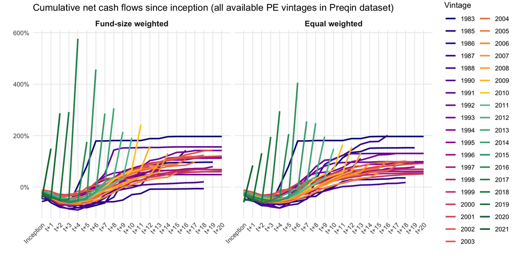

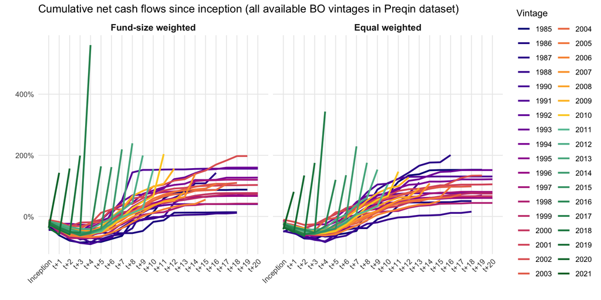

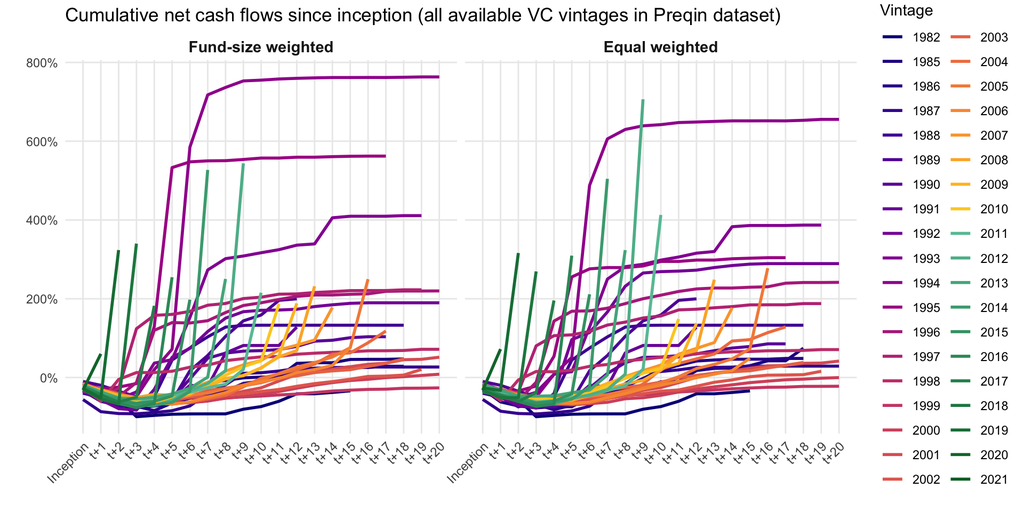

```r
library(ggplot2)
library(dplyr)

# Use all Private Equity vintages available in the dataset

# Helper function to process the cashflow data into percentage of commitment proxy
process_plot_data <- function(df, weight_label, fund_type) {
    df.subset <- df[df$type == fund_type, ]

    df.subset$Date <- as.Date(df.subset$Date)
    df.subset$Year <- as.numeric(format(df.subset$Date, "%Y"))
    df.subset$Age <- df.subset$Year - as.numeric(as.character(df.subset$Vintage))

    # Filter up to year 20 (t+20)
    df.subset <- df.subset[df.subset$Age >= 0 & df.subset$Age <= 20, ]

    agg <- aggregate(cbind(CF, CON) ~ Vintage + Age, data = df.subset, sum, na.rm = TRUE)
    agg <- agg[order(agg$Vintage, agg$Age), ]

    # Calculate cumulative net cashflows and cumulative contributions
    agg$CumCF <- unlist(tapply(agg$CF, agg$Vintage, cumsum))
    agg$CumCON <- unlist(tapply(agg$CON, agg$Vintage, cumsum))

    # Drawdown proxy: maximum drawn capital for the vintage (maximum absolute Cumulative CON)
    max_con <- aggregate(CumCON ~ Vintage, data = agg, function(x) max(abs(x)))
    colnames(max_con)[2] <- "MaxDrawn"
    agg <- merge(agg, max_con, by = "Vintage")

    # Scale to percent of proxy commitment
    agg$CumCF_Pct <- agg$CumCF / agg$MaxDrawn
    agg$Weighting <- weight_label
    return(agg)
}

for (f_type in c("PE", "BO", "VC")) {
    agg.fw <- process_plot_data(df.out.fw, "Fund-size weighted", f_type)
    agg.ew <- process_plot_data(df.out.ew, "Equal weighted", f_type)

    # Combine for side-by-side plotting
    agg.all <- rbind(agg.fw, agg.ew)
    agg.all$Vintage <- as.factor(agg.all$Vintage)
    agg.all$Weighting <- factor(agg.all$Weighting, levels = c("Fund-size weighted", "Equal weighted"))

    # Define custom color scale
    vintages <- levels(agg.all$Vintage)

    target_vintages <- as.character(2011:2021)
    target_vintages <- target_vintages[target_vintages %in% vintages]
    other_vintages <- setdiff(vintages, target_vintages)

    # Full plasma scale for older vintages
    other_colors <- scales::viridis_pal(option = "plasma", end = 0.9)(length(other_vintages))
    names(other_colors) <- other_vintages

    # Distinct teal/green gradient for 2011-2021 so they stand out but don't merge into a single solid color
    target_colors <- grDevices::colorRampPalette(c("#66c2a4", "#006d2c"))(length(target_vintages))
    names(target_colors) <- target_vintages

    vintage_colors <- c(other_colors, target_colors)

    # Create faceted plot
    p_jcurve <- ggplot(agg.all, aes(x = Age, y = CumCF_Pct, color = Vintage)) +
        geom_line(linewidth = 1) +
        facet_wrap(~Weighting) +
        scale_y_continuous(labels = scales::percent) +
        scale_x_continuous(breaks = 0:20, labels = c("Inception", paste0("t+", 1:20))) +
        theme_minimal() +
        theme(
            axis.text.x = element_text(angle = 45, hjust = 1, size = 9),
            legend.position = "right",
            strip.text = element_text(size = 11, face = "bold"),
            panel.grid.minor = element_blank()
        ) +
        scale_color_manual(values = vintage_colors) +
        labs(
            title = paste0("Cumulative net cash flows since inception (all available ", f_type, " vintages in Preqin dataset)"),
            y = "",
            x = "",
            color = "Vintage"
        )

    print(p_jcurve)

    # Export the plot as PDF
    ggsave(paste0("cumcashflows", f_type, ".pdf"), p_jcurve, width = 10, height = 5)
}
```